# Exploration 4: Estimators

Mannie Chomsin

17 April, 2020

```r
library("ggplot2")

# This randomly generates 25 random numbers between zero and one
one_sample <- runif(25)

# Note that the population variance formula does not have "n - 1"
bad_var <- function(x){
  N <- length(x)
  sigma_squared <- sum( (x - mean(x))^2 ) / N
  sigma_squared #return this number
}

# Note that the sample variance formula does have "n - 1"
good_var <- function(x){
  n <- length(x)
  s_squared <- sum( (x - mean(x))^2 ) / (n-1)
  s_squared #return this number
}
```

## Example

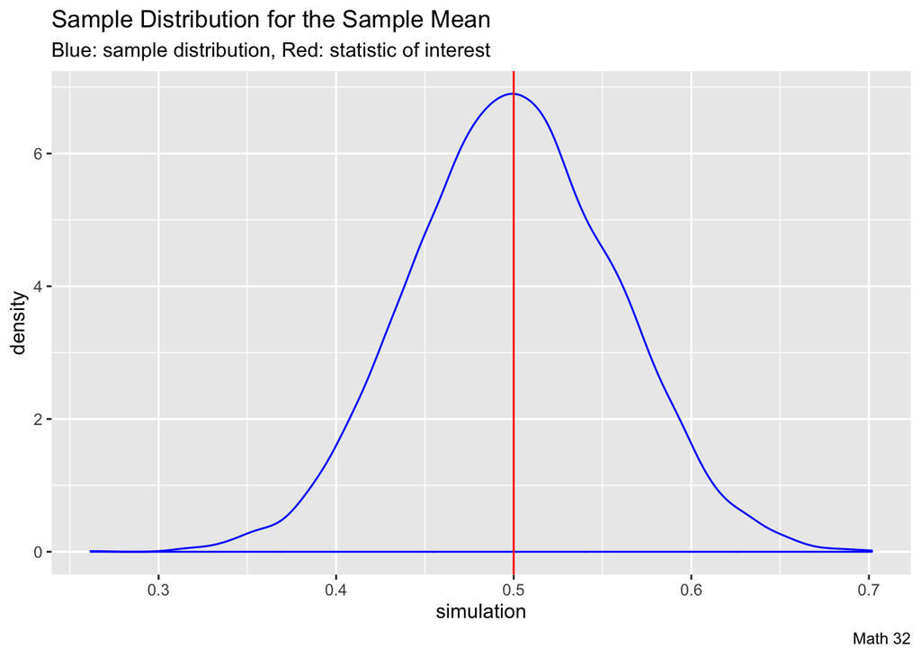

```r
true_mean <- 1/2

simulation <- replicate(10000, mean( runif(25) )) #generates 25 random numbers btw 0-1 then means them, repeat 1000 times (mean of means)
df <- data.frame(simulation)

ggplot(df, aes(x = simulation)) +
  geom_density(color = "blue") +
  geom_vline(xintercept = true_mean, color = "red") +
  labs(title = "Sample Distribution for the Sample Mean",
       subtitle = "Blue: sample distribution, Red: statistic of interest",
       caption = "Math 32")
```

Since the sample distribution empirically does seem to line up with the population mean, we say that the sample mean $\bar{x}$ is *unbiased*.

Repeat the simulation above, but with the an $Exp(1/32)$ distribution and the following estimators:

1. sample median `median()`

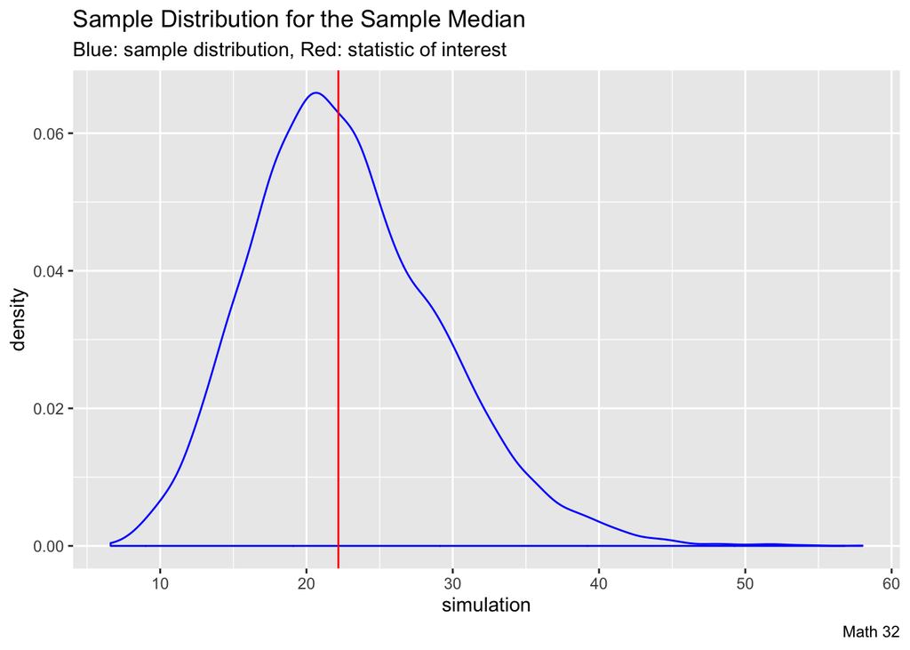

```r
true_median <- log(2)*32 #median of continuous exponential distribution ln(2) divided by rate

simulation <- replicate(10000, median( rexp(25,1/32) )) #rexp is exponential distribution
df <- data.frame(simulation)

ggplot(df, aes(x = simulation)) +
  geom_density(color = "blue") +
  geom_vline(xintercept = true_median, color = "red") +
  labs(title = "Sample Distribution for the Sample Median",
       subtitle = "Blue: sample distribution, Red: statistic of interest",
       caption = "Math 32")
```

This is probably unbiased of and estimator because the median is close to the middle/peak of the bell curve

2. population variance `bad_var()`

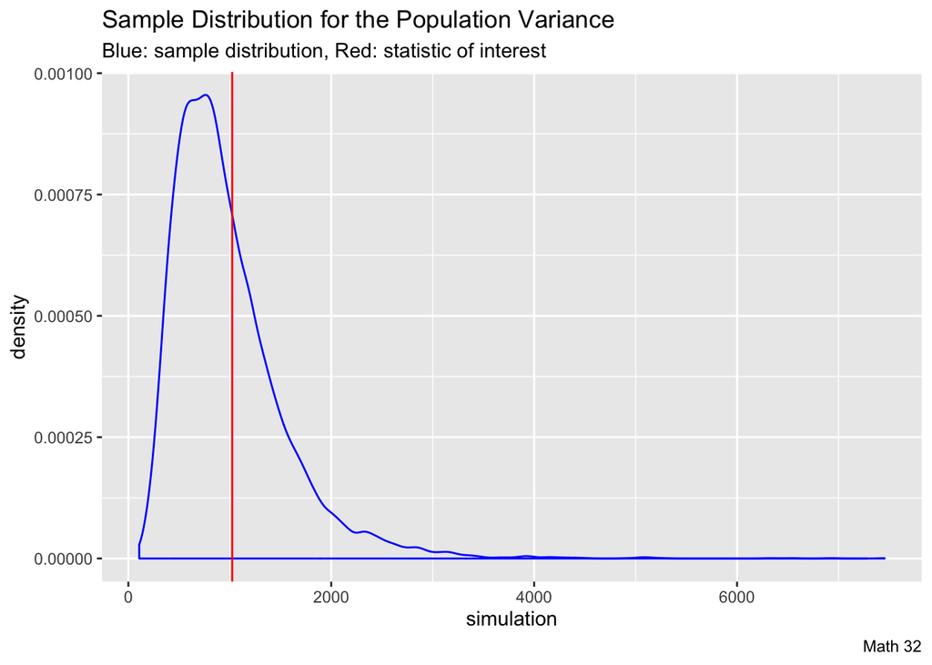

```r
true_var <- 32^2 #variance of exp distribution is 1/(lamda^2)

simulation <- replicate(10000, bad_var( rexp(25,1/32) ))
df <- data.frame(simulation)

ggplot(df, aes(x = simulation)) +
  geom_density(color = "blue") +
  geom_vline(xintercept = true_var, color = "red") +
  labs(title = "Sample Distribution for the Population Variance",
       subtitle = "Blue: sample distribution, Red: statistic of interest",
       caption = "Math 32")
```

3. sample variance `good_var()`

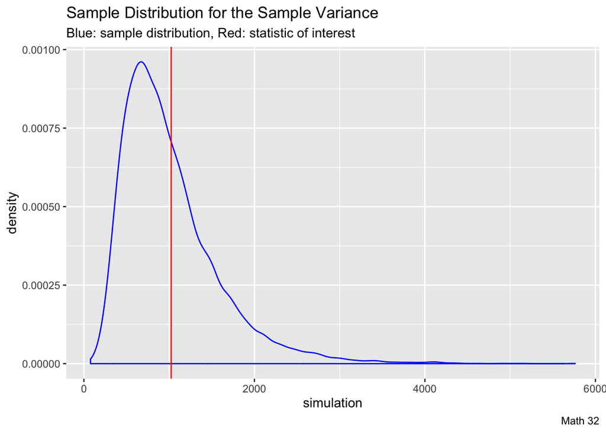

```r
true_var <- 32^2 #variance of exp distribution is 1/(lamda^2)

good_var <- function(x){
  n <- length(x)
  s_squared <- sum( (x - mean(x))^2 ) / (n-1)
  s_squared #return this number
}

simulation <- replicate(10000, good_var( rexp(25,1/32) ))
df <- data.frame(simulation)

ggplot(df, aes(x = simulation)) +
  geom_density(color = "blue") +
  geom_vline(xintercept = true_var, color = "red") +
  labs(title = "Sample Distribution for the Sample Variance",
       subtitle = "Blue: sample distribution, Red: statistic of interest",
       caption = "Math 32")
```

4. the sample standard deviation from `good_var()`

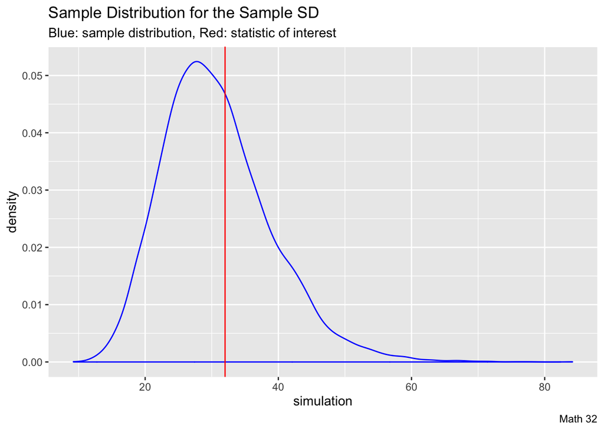

```r
true_sd <- 32 #standard deviation for exp is mean which is 1/lambda

simulation <- replicate(10000, sqrt(  good_var( rexp(25,1/32) )  ))
df <- data.frame(simulation)

ggplot(df, aes(x = simulation)) +
  geom_density(color = "blue") +
  geom_vline(xintercept = true_sd, color = "red") +
  labs(title = "Sample Distribution for the Sample SD",
       subtitle = "Blue: sample distribution, Red: statistic of interest",
       caption = "Math 32")
```

Unbiased estimator because the peak of the curve and the red prediction are pretty close

After each simulation, make an educated guess as to whether each estimator is biased or unbiased.

Verify that you have 5 graphs in total and replace “Math 32” with your full name in all of the graphs.

Finally, `knit` your work as either an HTML or PDF document, and upload that document back into the CatCourses assignment.